# ConnectFourFinal

## Connect Four

### First assignment: Informed and adversarial search strategies

#### Inteligência Artificial (CC2006) | PL5 | Grupo #8: Flávio Dantas (201905922), Hugo Almeida (201905410), Vítor Ferreira (201109428)

- 1. Implementing the Basics of Connect Four
  - 1.1. Class Design and Gameplay Logic
  - 1.2. Integrating AI and Player Customization
- 2. A* Inspired Approach
  - 2.1. Implementing the A* Agent
  - 2.2. Statistical Analysis and Discussion
- 3. Monte Carlo Tree Search
  - 3.1. Implementing the MCTS Agent
  - 3.2. Statistical Analysis and Discussion
- 4. References

## 1. Implementing the Basics of Connect Four

### 1.1. Class Design and Gameplay Logic

First, we started by designing a Python class ("ConnectFour") which encapsulates the functionality required to play a game of Connect Four in Python. This class manages the game flow, including initializing the game state, taking player inputs, validating moves, updating the board, checking for game-ending conditions, and alternating turns between two players. This setup allows for the integration of human players, AI, or a mix of both.

```python
class ConnectFour:
    # initializes the game board, current player, and game status
    def __init__(self, player1, player2):
        self.board = self.initialize_board()
        self.players = [player1, player2]
        self.current_player_index = 0
        self.game_over = False

    # creates a 6*7 game board filled with "-" to represent empty spaces
    def initialize_board(self):
        return [["-" for _ in range(7)] for _ in range(6)]

    # prints the current state of the board along with column numbers for player reference
    def display_board(self):
        print('\nGame Board\n')
        for row in self.board:
            print(' '.join(row))
        print('\n1 2 3 4 5 6 7\n')

    # checks if a move can be made in the given column
    def is_valid_move(self, column):
        return self.board[0][column] == "-"

    # updates the board with the current player's marker if the move is valid
    def make_move(self, column, marker):
        if self.is_valid_move(column):
            for row in reversed(range(6)):
                if self.board[row][column] == "-":
                    self.board[row][column] = marker
                    return True
        return False

    # checks for a win condition in all four directions (horizontal, vertical, ascending diagonal, descending diagonal)
    def check_win(self, marker):
        # horizontal
        for row in range(6):
            for col in range(4):
                if self.board[row][col] == marker and \
                self.board[row][col+1] == marker and \
                self.board[row][col+2] == marker and \
                self.board[row][col+3] == marker:
                    return True

        # vertical
        for col in range(7):
            for row in range(3):
                if self.board[row][col] == marker and \
                self.board[row+1][col] == marker and \
                self.board[row+2][col] == marker and \
                self.board[row+3][col] == marker:
                    return True

        # ascending diagonal (positive slope)
        for col in range(7-3):
            for row in range(3, 6):
                if self.board[row][col] == marker and \
                self.board[row-1][col+1] == marker and \
                self.board[row-2][col+2] == marker and \
                self.board[row-3][col+3] == marker:
                    return True

        # descending diagonal (negative slope)
        for col in range(7-3):
            for row in range(3):
                if self.board[row][col] == marker and \
                self.board[row+1][col+1] == marker and \
                self.board[row+2][col+2] == marker and \
                self.board[row+3][col+3] == marker:
                    return True

        return False


    # checks if the game is a draw
    def is_draw(self):
        return all(self.board[0][col] != "-" for col in range(7))


    # contains the game loop, handling turn taking, input validation, win/draw checking, and player switching
    def run_game(self):
        while not self.game_over:
            self.display_board()
            current_player = self.players[self.current_player_index]
            column_choice = current_player.make_move(self)

            if self.make_move(column_choice, current_player.marker):
                if self.check_win(current_player.marker):
                    self.display_board()
                    print(f"Player {current_player.marker} wins!")
                    self.game_over = True
                elif self.is_draw():
                    self.display_board()
                    print("The game is a draw!")
                    self.game_over = True
                else:
                    self.current_player_index = (self.current_player_index + 1) % 2
            else:
                print("Column is full. Try a different one.")
```

To summarize:

- Initialization (**init** method): the class initializes with two players, setting up the game board (a 6x7 grid represented by a list of lists filled with "-" to indicate empty spaces), tracking the current player, and a game status flag to check if the game has ended.
- Board Initialization (initialize_board method): this helper function creates the 6x7 game board.
- Displaying the Board (display_board method): prints the current state of the board, making it easier for players to visualize and make their next move. Column numbers are shown below the board for reference.
- Validating Moves (is_valid_move method): checks if a move (column selection) is valid, if the top cell in the chosen column is empty, indicating the column is not full and a move can be made.
- Making a Move (make_move method): updates the board with the current player's marker (assuming the move is valid) by placing the marker in the lowest available row of the chosen column.
- Win Condition Check (check_win method): checks for a win condition for the current player in all possible directions (horizontal, vertical, and both diagonal directions). A win is detected if four consecutive markers of the same player are found aligned.
- Draw Condition Check (is_draw method): determines if the game is a draw by checking if the top row is completely filled, implying no further moves are possible.
- Game Loop (run_game method): contains the main game loop that handles turn-taking, move validation, checking for win or draw conditions, and alternating between players after each valid move. The game loop continues until a win or draw condition is met, at which point the game ends and displays the outcome.

### 1.2. Integrating AI and Player Customization

Then, we implemented the Player base class along with its subclasses HumanPlayer and RandomAIAgent. Each subclass overrides the make_move method to implement distinct move selection logic, encapsulating the differences between human players and AI agents.

- Player: the base class for a player. It has a marker attribute and a make_move method that should be overridden by subclasses.
- HumanPlayer: inherits from Player and overrides the make_move method to allow a human player to input their move.
- RandomAIAgent: implements make_move to select a move randomly from available options.

```python
import random

# base class for a player, to be extended by specific player types (human, AI).
class Player:
    def __init__(self, marker):
        self.marker = marker # player's marker ("X" or "O")

    def make_move(self, board):
        pass  # to be implemented by subclasses

# human player
class HumanPlayer(Player):
    def make_move(self, board):
        while True:
            try:
                column_choice = int(input(f"Player {self.marker}'s turn. Choose a column (1-7): ")) - 1
                if 0 <= column_choice < 7 and board.is_valid_move(column_choice):
                    return column_choice
                else:
                    print("Invalid column. Please choose a column between 1 and 7, and ensure it's not full.")
            except ValueError:
                print("Please enter a number.") # non-integer input

# agent that randomly selects a valid move
class RandomAIAgent(Player):
    def make_move(self, board):
        # generates a list of valid columns
        valid_columns = [col for col in range(7) if board.is_valid_move(col)]
        # randomly selects from valid columns if any are available
        if valid_columns:
            return random.choice(valid_columns)
        else:
            return -1
```

At the start of the game, users are prompted to select the type for each player, either Human or AI. This feature supports various gameplay configurations including Human vs. Human, Human vs. AI, and AI vs. AI matchups, allowing players to customize their game experience to their preference or challenge level.

```python
def get_player_type(player_number):
    print(f"Select Player {player_number} type:")
    print("1: Human")
    print("2: AI")

    while True:
        try:
            # prompts user for input to select the player type
            player_type = int(input("Enter 1 for Human, 2 for AI: "))

            # returns a HumanPlayer object if the user inputs 1
            if player_type == 1:
                return HumanPlayer("X" if player_number == 1 else "O")
            # returns a RandomAIPlayer object if the user inputs 2
            elif player_type == 2:
                return RandomAIAgent("X" if player_number == 1 else "O")
            else:
                print("Invalid selection. Please enter 1 for Human or 2 for AI.")
        except ValueError:
            print("Invalid input. Please enter a number (1 or 2).")  # non-integer input
```

## 2. A* Inspired Approach

### 2.1. Implementing the A* Agent

Typically, A* is associated with pathfinding problems, where the goal is to find the shortest path from a start node to a goal node in a graph, considering various costs associated with moving from one node to another. It combines the actual cost to reach a node (g(n)) and a heuristic estimate of the cost to reach the goal from that node (h(n)).

In our adaptation for Connect Four, we followed these principles:

- Heuristic Evaluation (h(n)): the use of a heuristic evaluation function to determine the desirability of board states is similar to estimating the cost to reach the goal in traditional A* usage. The scoring rules based on potential winning configurations (based on R. L. Rivest, Game Tree Searching by Min/Max Approximation, AI 34 [1988], pp. 77-96) act as the heuristic, guiding the AI's move selection towards those that increase its chances of winning.
- Considering Opponent Moves: simulating the opponent's best response and incorporating it into the decision-making process introduces an element of predicting future states, which is conceptually similar to looking ahead in a pathfinding context. This can be likened to evaluating the cost of a path considering future obstacles, but in a competitive game scenario rather than a spatial navigation problem.
- Decision Making: the process of selecting a move based on both the current score and the anticipated opponent response reflects a balance between immediate benefit and strategic positioning, mirroring the balance between g(n) and h(n) in traditional A*. The decision to make a move that optimizes the effective score parallels the A* strategy of selecting the node with the lowest f(n) = g(n) + h(n) to progress towards the goal.

While this implementation does not employ A* in its standard form of navigating spatial graphs, we believe that it creatively adapts the underlying concepts of A*, utilizing heuristic evaluations to guide decision-making and considering the impact of future states (via opponent moves) to the strategic environment of Connect Four.

The implementation is found below:

```python
# an implementation of an AI agent inspired by A*
class AStarAgent(Player):
    def __init__(self, marker):
        super().__init__(marker)
        # assigns the opponent's marker based on the agent's own marker
        self.opponent_marker = 'O' if marker == 'X' else 'X'

    # evaluates the game board from the perspective of the given marker
    def heuristic_evaluation(self, game, marker):
        score = 0  # initializes the score to 0
        turn_bonus = 16

        # loops through each cell on the board
        for row in range(6):
            for col in range(7):
                # horizontal
                if col + 3 < 7:
                    score += self.evaluate_segment(game, row, col, 0, 1, marker)
                # vertical
                if row + 3 < 6:
                    score += self.evaluate_segment(game, row, col, 1, 0, marker)
                # ascending diagonal
                if row - 3 >= 0 and col + 3 < 7:
                    score += self.evaluate_segment(game, row, col, -1, 1, marker)
                # descending diagonal
                if row + 3 < 6 and col + 3 < 7:
                    score += self.evaluate_segment(game, row, col, 1, 1, marker)

        return score + turn_bonus # returns the total score

    # helper method to evaluate a segment of four cells
    def evaluate_segment(self, game, row, col, d_row, d_col, marker):
        # creates a segment of four cells based on the direction specified by d_row and d_col
        segment = [game.board[row + i * d_row][col + i * d_col] for i in range(4)]
        # assigns a score to the segment based on its composition
        return self.score_segment(segment, marker, self.opponent_marker)

    # assigns a score to the segment based on its composition
    def score_segment(self, segment, marker, opponent_marker):
        if segment.count(marker) == 4 and segment.count('-') == 0:
            return 512
        elif segment.count(marker) == 3 and segment.count('-') == 1:
            return 50
        elif segment.count(marker) == 2 and segment.count('-') == 2:
            return 10
        elif segment.count(marker) == 1 and segment.count('-') == 3:
            return 1
        elif segment.count(opponent_marker) == 4 and segment.count('-') == 0:
            return -512
        elif segment.count(opponent_marker) == 3 and segment.count('-') == 1:
            return -50
        elif segment.count(opponent_marker) == 2 and segment.count('-') == 2:
            return -10
        elif segment.count(opponent_marker) == 1 and segment.count('-') == 3:
            return -1
        return 0

    # simulates the opponent's best possible move and returns its score
    def simulate_opponent_best_move(self, game):
        best_opponent_score = float('-inf')  # initializes to the lowest possible score
        for col in game.get_valid_moves():  # iterates through all valid moves
            temp_game = game.copy()  # makes a copy of the game to simulate the move
            temp_game.make_move(col, self.opponent_marker)  # simulates the opponent's move
            score = self.heuristic_evaluation(temp_game, self.opponent_marker)  # evaluates the board after the move
            if score > best_opponent_score:  # if the move is better than the current best, updates the best score
                best_opponent_score = score
        return best_opponent_score  # returns the best score achievable by the opponent

    # chooses the best move based on the agent's heuristic evaluation
    def make_move(self, game):
        best_score = float('-inf')  # initializes the best score to the lowest possible score
        best_moves = []  # initializes a list to keep track of the best moves

        # evaluates each valid move
        for col in game.get_valid_moves():
            temp_game = game.copy()  # copy the game to simulate the move
            temp_game.make_move(col, self.marker)  # makes the simulated move
            current_score = self.heuristic_evaluation(temp_game, self.marker)  # evaluates the move's score
            opponent_best_score = self.simulate_opponent_best_move(temp_game)  # simulates the opponent's best response
            effective_score = current_score - opponent_best_score  # calculates the effective score considering the opponent's best move

            # updates the list of best moves based on the effective score
            if effective_score > best_score:
                best_score = effective_score  # update the best score
                best_moves = [col]  # starts a new list with this column as the best move
            elif effective_score == best_score:
                best_moves.append(col)  # adds this column to the list of best moves if it matches the best score

        # chooses randomly among the best moves if there are multiple
        return random.choice(best_moves) if best_moves else -1
```

Besides the agent's implementation, we changed the ConnectFour class by incorporating methods that create deep copies of the game state and identify valid moves:

```python
# creates a deep copy of the game state
def copy(self):
    new_game = ConnectFour(self.players[0], self.players[1])
    new_game.board = [row[:] for row in self.board]
    new_game.current_player_index = self.current_player_index
    new_game.game_over = self.game_over
    return new_game

# returns a list of columns that can accept another marker
def get_valid_moves(self):
    return [c for c in range(7) if self.is_valid_move(c)]
```

We also performed some changes in the main file, allowing for different modes of interaction, including AI vs. AI simulations, playing against an AI, and watching an AI vs. AI match. The simulate_games function was added to enable the simulation of multiple games between two AI agents, providing insights into their effectiveness over a large number of matches. This feature is essential for testing and comparing AI strategies.

```python
# displays options for AI player type selection
def get_agent_type():
    print("Select AI type:")
    print("1. Random AI Agent")
    print("2. A* Agent")
    selection = input("Enter your choice (1/2): ").strip()

    if selection == "1":
        return RandomAIAgent
    elif selection == "2":
        return AStarAgent
    else:
        print("Invalid selection, defaulting to Random AI Player.")
        return RandomAIAgent  # ensures a default is returned


# simulates a given number of games between two player types, tracking wins and draws
def simulate_games(num_games, player1_type, player2_type):
    wins_for_X = 0
    wins_for_O = 0
    draws = 0

    for _ in range(num_games):
        player1 = player1_type('X')
        player2 = player2_type('O')
        game = ConnectFour(player1, player2)

        while not game.game_over:
            current_player = game.players[game.current_player_index]
            column_choice = current_player.make_move(game)

            if game.make_move(column_choice, current_player.marker):
                if game.check_win(current_player.marker):
                    if current_player.marker == 'X':
                        wins_for_X += 1
                    else:
                        wins_for_O += 1
                    game.game_over = True
                elif game.is_draw():
                    draws += 1
                    game.game_over = True
            game.current_player_index = (game.current_player_index + 1) % 2

    return wins_for_X, wins_for_O, draws
```

### 2.2. Statistical Analysis and Discussion

```python
import matplotlib.pyplot as plt
```

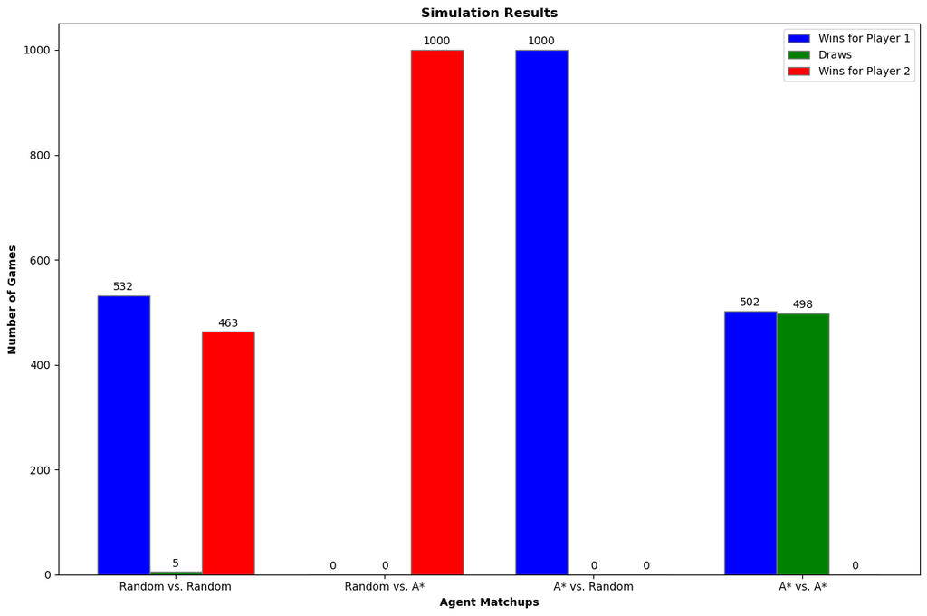

```python
# simulation results
agents = ['Random vs. Random', 'Random vs. A*', 'A* vs. Random', 'A* vs. A*']
wins_for_player1 = [532, 0, 1000, 502]
draws = [5, 0, 0, 498]
wins_for_player2 = [463, 1000, 0, 0]

# sets up the bar width
bar_width = 0.25

# sets up the index for the groups
r1 = range(len(agents))
r2 = [x + bar_width for x in r1]
r3 = [x + bar_width for x in r2]

# creates the plots
plt.figure(figsize=(12, 8))
plt.bar(r1, wins_for_player1, color='b', width=bar_width, edgecolor='grey', label='Wins for Player 1')
plt.bar(r2, draws, color='g', width=bar_width, edgecolor='grey', label='Draws')
plt.bar(r3, wins_for_player2, color='r', width=bar_width, edgecolor='grey', label='Wins for Player 2')

# adds labels
plt.xlabel('Agent Matchups', fontweight='bold')
plt.xticks([r + bar_width for r in range(len(agents))], agents)
plt.ylabel('Number of Games', fontweight='bold')
plt.title('Simulation Results', fontweight='bold')

# adds value labels on top of each bar
for i in range(len(agents)):
    plt.text(r1[i], wins_for_player1[i] + 10, str(wins_for_player1[i]), ha='center')
    plt.text(r2[i], draws[i] + 10, str(draws[i]), ha='center')
    plt.text(r3[i], wins_for_player2[i] + 10, str(wins_for_player2[i]), ha='center')

# adjusts y-axis limit if necessary
plt.ylim(0, max(wins_for_player1 + wins_for_player2 + draws) + 50)

# creates legend & shows graph
plt.legend()
plt.tight_layout()
plt.show()
```

The simulation involved four distinct matchups between agents employing random move strategies and those utilizing the A* heuristic approach in a Connect Four game environment. The outcomes are represented through the total number of wins for each player, as well as the occurrences of draws, across 1000 simulated games per matchup. The agents are categorized into matchups as follows: Random vs. Random, Random vs. A*, A* vs. Random, and A* vs. A*.

Based on the results of the simulations, it is clear that the performance of the A* agent is significantly superior to that of the Random agent.

Random vs. Random:

- This matchup was very balanced, as expected, since both players are making moves randomly. We noticed a slight advantage to Player 1, which could be attributed to the first-move advantage in a game like Connect Four.

Random vs. A*:

- When a Random agent competes against an A* agent, the A* agent wins all the games. This demonstrates the effectiveness of the A* agent's strategy and heuristic evaluation over random move selection.

A* vs. Random:

- These results further confirm the superiority of the A* agent's strategy.

A* vs. A*:

- When two A* agents competed, the games concluded either in a win for Player 1 (502 wins) or a draw (498), with Player 2 proving unable to achieve any victories. This pattern suggests that while the A* heuristic ensures a high level of strategic gameplay, the first-move advantage becomes significantly pronounced when both players possess equal strategic capabilities. The high number of draws indicates closely matched decision-making processes.

Based on the results, we decided to perform some changes in the make_move method of the agent in search of a more deterministic approach:

```python
    # chooses the best move based on the agent's heuristic evaluation
    def make_move(self, game):
        best_score = float('-inf')  # initializes the best score to the lowest possible score
        best_move = None  # initializes best_move to None

        # evaluates each valid move
        for col in game.get_valid_moves():
            temp_game = game.copy()  # copy the game to simulate the move
            temp_game.make_move(col, self.marker)  # makes the simulated move
            current_score = self.heuristic_evaluation(temp_game, self.marker)  # evaluates the move's score
            opponent_best_score = self.simulate_opponent_best_move(temp_game)  # simulates the opponent's best response
            effective_score = current_score - opponent_best_score  # calculates the effective score considering the opponent's best move.

            # updates the best move based on the effective score
            if effective_score > best_score:
                best_score = effective_score  # updates the best score.
                best_move = col  # updates best_move to this column as the best move.

        # returns the best move if it exists, otherwise returns -1.
        return best_move if best_move is not None else -1
```

In this modified version, instead of maintaining a list of best moves and randomly choosing one, the code now keeps track of a single best_move. When a move is found with a higher effective score than any previously evaluated move, the code updates best_move to this new best move directly. This ensures that the first move found with the highest score is chosen, eliminating randomness from the decision process. If there are multiple moves with the same highest score, this version will choose the first one it encounters. In a deterministic setup, if one agent starts with an advantage (such as being the first to move), and both agents make optimal moves, the initial advantage can be enough to secure a win, assuming there are no mechanisms within the game that inherently balance this advantage out. That is why, when we tested two A* agents against each other we obtained the following result:

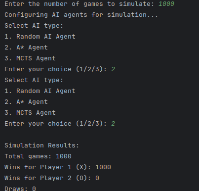

```python
from IPython.display import Image
Image(filename='prnt.png')
```

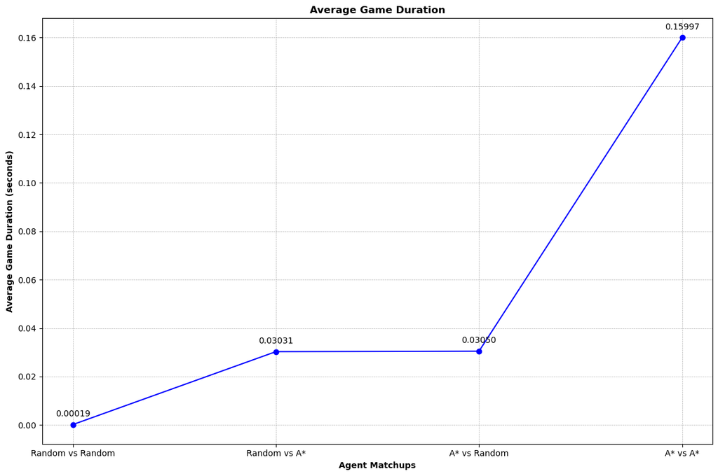

```python
configurations = [
    'Random vs Random',
    'Random vs A*',
    'A* vs Random',
    'A* vs A*'
]

configuration_indexes = range(len(configurations))

average_durations = [
    0.00019004440307617188,
    0.03030767011642456,
    0.03049675154685974,
    0.15997280836105346
]

plt.figure(figsize=(12, 8))
plt.plot(configuration_indexes, average_durations, marker='o', linestyle='-', color='b')

plt.title('Average Game Duration', fontweight='bold')
plt.xlabel('Agent Matchups', fontweight='bold')
plt.ylabel('Average Game Duration (seconds)', fontweight='bold')
plt.xticks(configuration_indexes, configurations)

plt.grid(True, which='both', linestyle='--', linewidth=0.5)

for i, duration in enumerate(average_durations):
    plt.annotate(f'{duration:.5f}', (configuration_indexes[i], average_durations[i]), textcoords="offset points", xytext=(0,10), ha='center')

plt.tight_layout()
plt.show()
```

This line plot demonstrates the progression in average game durations across the various agent matchups.

- The plot starts with the Random vs. Random matchup, showing the shortest duration due to the simplicity of decision-making.
- As we introduce the A* inspired strategy in matchups against a random strategy, there's a noticeable jump in duration, indicative of the increased computation required for heuristic evaluations.
- The most significant increase is observed in the A* vs. A* matchup. This results in the longest duration, highlithing the computational intensity of strategic decision-making when both sides employ complex evaluations.

## 3. Monte Carlo Tree Search

### 3.1. Implementing the MCTS Agent

The Monte Carlo Tree Search (MCTS) algorithm is a versatile decision-making tool often associated with complex games like Go, Chess, and, as adapted here, Connect Four. MCTS navigates the vast search spaces of these games by balancing between exploring new moves and exploiting known advantageous ones. This balance is achieved through a series of phases: Selection, Expansion, Simulation, and Backpropagation, each serving a distinct purpose in the algorithm's strategy to find the most promising move from a given game state.

In our adaptation for Connect Four, we implemented the following classes:

MCTSNode Class:

- Initialization (**init**): each MCTSNode represents a state in the game with links to parent and child nodes, reflecting the game's current state, the move that led there, and potential future moves.
- Upper Confidence Bound (UCT) Score (uct_score): this function calculates the UCT score, guiding the selection process towards nodes that strike an optimal balance between exploration of less-visited nodes and exploitation of nodes known to lead to winning outcomes.
- Expansion Readiness (is_fully_expanded): by checking if there are any unexplored moves left, this method determines whether a node can be expanded, ensuring that the search tree grows to explore all possible outcomes.
- Terminal State Check (is_terminal): this method assesses whether the current game state is a win, loss, or draw, facilitating the algorithm's decision on when to stop expanding and start simulating.
- Best Child Selection (best_child): Identifies the child node with the highest UCT score for further exploration, embodying the exploitation phase by selecting the most promising path based on current knowledge.

MonteCarloTreeSearch Class:

- Initialization (**init**): Establishes the root of the MCTS tree, marking the beginning of the search process from the current state of the Connect Four game.
- Node Selection (select_node): implements the selection phase by traversing the tree from the root, using the UCT scores to guide it towards promising nodes until it finds an expandable node or reaches a terminal state.
- Node Expansion (expand_node): upon finding a node with unexplored moves, this method expands the tree by creating a new child node for one of these moves, simulating the exploration of a new possible future state in the game.
- simulation (simulate): this phase plays out the game from the state of the selected node, making random moves until a terminal state is reached. This simulation phase helps assess the potential of a node by exploring its possible outcomes without the need for exhaustive search.
- Backpropagation (backpropagate): after a simulation, this method updates the win/visit counts up the tree, informing the algorithm of the simulated outcome's value and allowing it to better assess the potential of earlier moves.
- Search Execution (run_search): runs the MCTS process through specified iterations, utilizing selection, expansion, simulation, and backpropagation to ultimately decide on the most promising move from the root node's perspective.

MCTSAgent Class:

- represents the agent that utilizes the Monte Carlo Tree Search (MCTS) algorithm to decide on moves within the game of Connect Four.

```python
import math
import random


# represents a node in the Monte Carlo Tree Search (MCTS) algorithm
class MCTSNode:
    def __init__(self, game_state, parent=None, move=None, exploration_constant=1.41):
        self.game_state = game_state.copy()  # duplicate of the game state to avoid altering the original game state
        self.parent = parent  # the parent node of the current node, None if root
        self.move = move  # the move that led to the creation of this node from the parent
        self.children = []  # child nodes of this node
        self.wins = 0  # number of wins recorded from this node
        self.visits = 0  # number of times this node has been visited during search
        self.unexplored_moves = game_state.get_valid_moves()  # moves not yet explored from this node
        self.exploration_constant = exploration_constant  # balances exploration/exploitation

    def uct_score(self, total_simulations, exploration_constant=None):
        # calculates the Upper Confidence Bound 1 applied to trees (UCT) score
        if exploration_constant is None:
            exploration_constant = self.exploration_constant
        if self.visits == 0:
            return float('inf')  # infinite score for unvisited nodes to ensure they are visited
        return self.wins / self.visits + exploration_constant * (math.log(total_simulations) / self.visits) ** 0.5

    def is_fully_expanded(self):
        # checks if all possible moves have been explored from this node
        return len(self.unexplored_moves) == 0

    def is_terminal(self):
        # checks if this node represents a terminal state of the game
        return self.game_state.is_terminal()

    def best_child(self, exploration_constant=None):
        # selects the best child node based on the UCT score
        if exploration_constant is None:
            exploration_constant = self.exploration_constant
        total_simulations = sum(child.visits for child in self.children)
        return max(
            self.children,
            key=lambda child: child.uct_score(total_simulations, exploration_constant)
        )


# MCTS algorithm implementation
class MonteCarloTreeSearch:
    def __init__(self, root):
        self.root = root  # initializes the root of the Monte Carlo Tree Search

    def select_node(self):
        # selects the node to explore based on the current state of the MCTS tree
        current_node = self.root
        while not current_node.is_terminal():  # continues until a terminal node is reached
            if not current_node.is_fully_expanded():
                # expands the current node if it has unexplored children
                return self.expand_node(current_node)
            else:
                # otherwise, selects the best child based on UCT score
                current_node = current_node.best_child()
        return current_node  # returns the terminal or fully expanded node

    def expand_node(self, node):
        # expands a node by creating a new child node from an unexplored move
        move = node.unexplored_moves.pop()  # removes and retrieves the last unexplored move
        new_state = node.game_state.copy()  # creates a copy of the current game state
        # attempts to apply the move to the new game state
        success = new_state.make_move(move, new_state.players[new_state.current_player_index].marker)

        if success:
            # updates the player index and checks for a win or draw if the move is successful
            new_state.current_player_index = (new_state.current_player_index + 1) % 2
            new_state.game_over = new_state.check_win(new_state.players[0].marker) or new_state.check_win(
                new_state.players[1].marker) or new_state.is_draw()
            child_node = MCTSNode(new_state, parent=node, move=move)  # creates a new child node
            node.children.append(child_node)  # adds the new child node to the current node's children
            return child_node
        else:
            return None  # returns None if the move was not successful

    def simulate(self, node):
        # simulates a game from the current node to a terminal state
        simulation_state = node.game_state.copy()  # copies the game state for the simulation
        while not simulation_state.is_terminal():
            # continues simulation until a terminal state is reached
            possible_moves = simulation_state.get_valid_moves()  # gets all valid moves for the current state
            move = random.choice(possible_moves)  # randomly selects one of the valid moves
            simulation_state.make_move(move, simulation_state.players[simulation_state.current_player_index].marker)
            simulation_state.current_player_index = (simulation_state.current_player_index + 1) % 2  # switches players
        return simulation_state.get_result()  # returns the result of the simulation

    def backpropagate(self, node, result):
        # backpropagates the simulation result through the tree, updating node statistics
        while node is not None:  # continues until the root node is reached
            node.visits += 1  # increments the visit count for the node
            if node.move is not None:  # checks if the node is not the root (the root node does not have a move)
                last_move_player_marker = node.game_state.players[
                    (node.game_state.current_player_index + 1) % 2].marker
                if result == last_move_player_marker:  # increments the win count if the result matches the last move marker
                    node.wins += 1
            node = node.parent  # moves to the parent node

    def run_search(self, iterations):
        # runs the MCTS algorithm for a specified number of iterations
        for _ in range(iterations):
            selected_node = self.select_node()  # selects a node for exploration
            result = self.simulate(selected_node)  # simulates a playthrough from the selected node
            self.backpropagate(selected_node, result)  # backpropagates the result through the tree

        # selects the best move to make from the root node, using an exploration constant of 0 for exploitation
        best_move = self.root.best_child(exploration_constant=0).move
        return best_move  # returns the best move found


# agent that uses the MCTS algorithm
class MCTSAgent(Player):
    def make_move(self, game):
        root = MCTSNode(game)
        mcts = MonteCarloTreeSearch(root)
        best_move = mcts.run_search(iterations=1000) # adjustable parameter
        return best_move
```

Besides the agent's implementation, we changed the ConnectFour class by incorporating methods used by the MCTS agent:

```python
# checks if the game is over
def is_terminal(self):
    return self.game_over or self.is_draw()

# determines the result of the game
def get_result(self):
    if self.check_win(self.players[0].marker):
        return self.players[0].marker
    elif self.check_win(self.players[1].marker):
        return self.players[1].marker
    else:
        return "draw"
```

### 3.2. Statistical Analysis and Discussion

For the evaluation of the Monte Carlo Tree Search (MCTS) Agent, we conducted a simulation consisting of 200 matchups, evenly split between Player 1 and Player 2 positions, against both the Random Agent and the A* Agent. To assess the MCTS Agent's performance, we systematically varied the number of iterations employed in the Monte Carlo simulations. In all of the following simulations the exploration constant was set to 1.41 (approximation of $\sqrt{2}$). This approach allowed us to observe the impact of iteration count on the effectiveness of the MCTS strategy when confronting different types of opponents.

```python
import seaborn as sns
import numpy as np
```

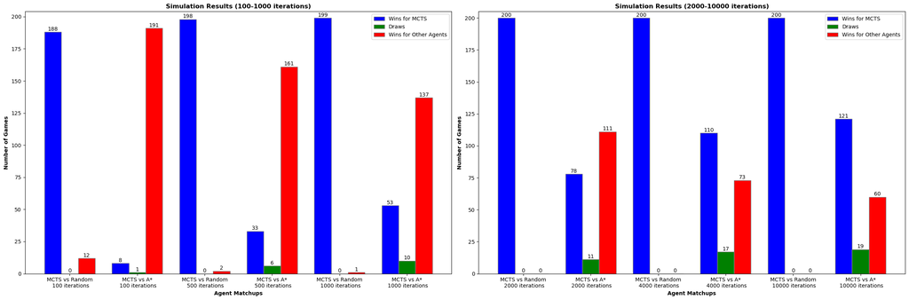

```python
# first plot data
agents_1 = ['MCTS vs Random\n 100 iterations',
            'MCTS vs A*\n 100 iterations',
            'MCTS vs Random\n 500 iterations',
            'MCTS vs A*\n 500 iterations',
            'MCTS vs Random\n 1000 iterations',
            'MCTS vs A*\n 1000 iterations']
wins_for_X_1 = [188, 8, 198, 33, 199, 53]
wins_for_O_1 = [12, 191, 2, 161, 1, 137]
draws_1 = [0, 1, 0, 6, 0, 10]

# second plot data
agents_2 = ['MCTS vs Random\n 2000 iterations',
            'MCTS vs A*\n 2000 iterations',
            'MCTS vs Random\n 4000 iterations',
            'MCTS vs A*\n 4000 iterations',
            'MCTS vs Random\n 10000 iterations',
            'MCTS vs A*\n 10000 iterations']
wins_for_X_2 = [200, 78, 200, 110, 200, 121]
wins_for_O_2 = [0, 111, 0, 73, 0, 60]
draws_2 = [0, 11, 0, 17, 0, 19]

bar_width = 0.25

fig, axs = plt.subplots(1, 2, figsize=(24, 8))

# first plot
r1_1 = range(len(agents_1))
r2_1 = [x + bar_width for x in r1_1]
r3_1 = [x + bar_width for x in r2_1]

axs[0].bar(r1_1, wins_for_X_1, color='b', width=bar_width, edgecolor='grey', label='Wins for MCTS')
axs[0].bar(r2_1, draws_1, color='g', width=bar_width, edgecolor='grey', label='Draws')
axs[0].bar(r3_1, wins_for_O_1, color='r', width=bar_width, edgecolor='grey', label='Wins for Other Agents')

axs[0].set_xlabel('Agent Matchups', fontweight='bold')
axs[0].set_xticks([r + bar_width for r in range(len(agents_1))])
axs[0].set_xticklabels(agents_1, ha='center')
axs[0].set_ylabel('Number of Games', fontweight='bold')
axs[0].set_title('Simulation Results (100-1000 iterations)', fontweight='bold')
axs[0].set_ylim(0, max(wins_for_X_1 + wins_for_O_1 + draws_1) + 5)

for i in range(len(agents_1)):
    axs[0].text(r1_1[i], wins_for_X_1[i] + 1, str(wins_for_X_1[i]), ha='center')
    axs[0].text(r2_1[i], draws_1[i] + 1, str(draws_1[i]), ha='center')
    axs[0].text(r3_1[i], wins_for_O_1[i] + 1, str(wins_for_O_1[i]), ha='center')

# second plot
r1_2 = range(len(agents_2))
r2_2 = [x + bar_width for x in r1_2]
r3_2 = [x + bar_width for x in r2_2]

axs[1].bar(r1_2, wins_for_X_2, color='b', width=bar_width, edgecolor='grey', label='Wins for MCTS')
axs[1].bar(r2_2, draws_2, color='g', width=bar_width, edgecolor='grey', label='Draws')
axs[1].bar(r3_2, wins_for_O_2, color='r', width=bar_width, edgecolor='grey', label='Wins for Other Agents')

axs[1].set_xlabel('Agent Matchups', fontweight='bold')
axs[1].set_xticks([r + bar_width for r in range(len(agents_2))])
axs[1].set_xticklabels(agents_2, ha='center')
axs[1].set_ylabel('Number of Games', fontweight='bold')
axs[1].set_title('Simulation Results (2000-10000 iterations)', fontweight='bold')
axs[1].set_ylim(0, max(wins_for_X_2 + wins_for_O_2 + draws_2) + 5)

for i in range(len(agents_2)):
    axs[1].text(r1_2[i], wins_for_X_2[i] + 1, str(wins_for_X_2[i]), ha='center')
    axs[1].text(r2_2[i], draws_2[i] + 1, str(draws_2[i]), ha='center')
    axs[1].text(r3_2[i], wins_for_O_2[i] + 1, str(wins_for_O_2[i]), ha='center')

axs[0].legend()
axs[1].legend()
plt.tight_layout()
plt.show()
```

[figure not shown]

```python
win_rates_random = [188/200, 198/200, 199/200, 200/200, 200/200, 200/200]
win_rates_a_star = [8/200, 33/200, 53/200, 78/200, 110/200, 120/200]

win_rates = np.array([win_rates_random, win_rates_a_star])

opponents = ['Random AI', 'A*']
iterations = [100, 500, 1000, 2000, 4000, 10000]

plt.figure(figsize=(10, 6))
sns.heatmap(win_rates, annot=True, cmap='viridis', xticklabels=iterations, yticklabels=opponents, fmt=".2%", cbar_kws={'label': 'Win Rate'})
plt.xlabel('Number of Iterations', fontweight='bold')
plt.ylabel('Opponent', fontweight='bold')
plt.title('Win Rates for MCTS vs. Different Opponents', fontweight='bold')
plt.tight_layout()
plt.show()
```

Given these results we can conclude that:

- At Lower Iterations (100-1000): The MCTS Agent struggles against the A* Agent, winning significantly fewer games. This indicates that the depth of search or exploration at these lower iteration counts is insufficient to consistently outperform the heuristic-based strategies employed by the A* Agent.
- Improvement at Medium Iterations (2000): At 2000 iterations, there's a noticeable improvement in the MCTS Agent's performance against the A* Agent, but it still falls short of achieving a majority of wins. This suggests that while the additional iterations provide a better strategic overview and potential moves, they are still not enough.
- Superiority at Higher Iterations (4000-10000): It's at the 4000 iterations mark and beyond that the MCTS Agent begins to consistently outperform the A* Agent. With 4000 iterations, the MCTS Agent secures 110 wins against the A* Agent, and this success rate continues to improve, reaching 121 wins at 10000 iterations. This trend signifies the point at which the MCTS's ability to explore and exploit the game tree becomes superior to the A* Agent's informed strategy.

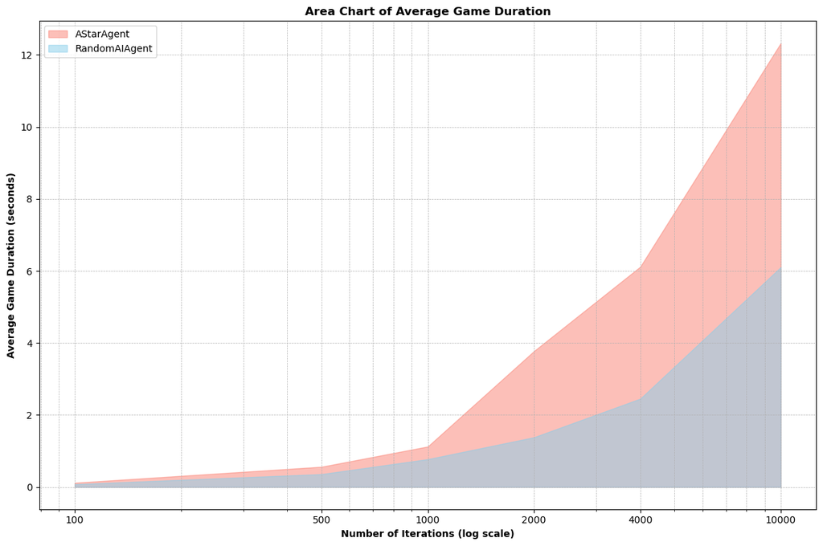

```python
opponents = ['RandomAIAgent', 'AStarAgent']
iterations = [100, 500, 1000, 2000, 4000, 10000]
average_durations = {
    'RandomAIAgent': [0.077604, 0.356064, 0.771258, 1.379500, 2.451838, 6.104283],
    'AStarAgent': [0.116861, 0.560388,1.122734, 3.7736026, 6.116285, 12.325938]
}

plt.figure(figsize=(12, 8))

colors = {
    'RandomAIAgent': 'skyblue',
    'AStarAgent': 'salmon'
}

plt.fill_between(iterations, 0, average_durations['AStarAgent'], alpha=0.5, label='AStarAgent', color=colors['AStarAgent'])

plt.fill_between(iterations, 0, average_durations['RandomAIAgent'], alpha=0.5, label='RandomAIAgent', color=colors['RandomAIAgent'])

plt.title('Area Chart of Average Game Duration', fontweight='bold')
plt.xlabel('Number of Iterations (log scale)', fontweight='bold')
plt.ylabel('Average Game Duration (seconds)', fontweight='bold')
plt.xscale('log')
plt.xticks(iterations, labels=iterations)
plt.legend(loc='upper left')
plt.grid(True, which='both', linestyle='--', linewidth=0.5)
plt.tight_layout()
plt.show()
```

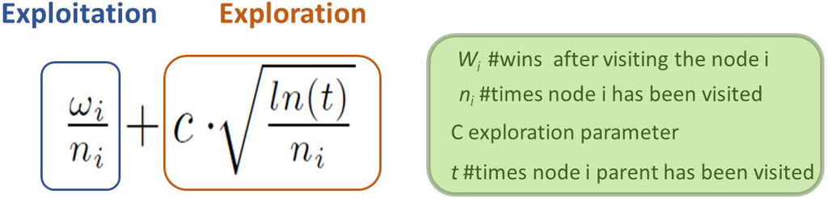

```python
from IPython.display import Image
Image(filename='UCT.png')
```

As we have stated before, the results displayed above were obtained by setting the exploration parameter to 1.41 (approximation of $\sqrt{2}$). Then, we decided to further investigate what would happen if we increased the parameter (favouring exploration) or decreased the parameter (favouring exploitation). Below, we compare the performance of the MCTS Agent against the A* Agent in 1000, 2000, 4000 and 10000 iterations by changing the exploration parameter to 1.0 and 2.12 (1.5 * $\sqrt{2}$).

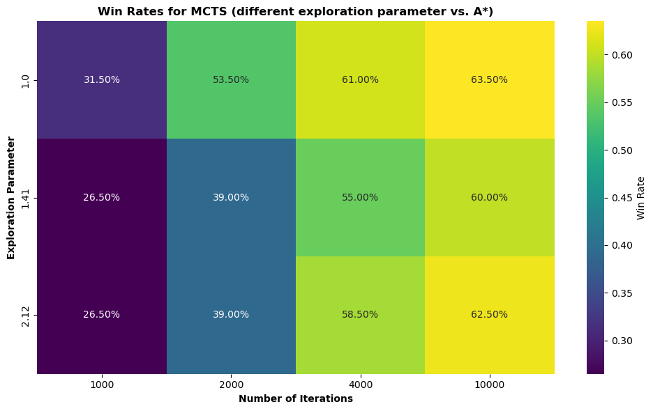

```python
win_rates_1_0 = [63/200, 107/200, 122/200, 127/200]
win_rates_1_41 = [53/200, 78/200, 110/200, 120/200]
win_rates_2_12 = [53/200, 78/200, 117/200, 125/200]

win_rates = np.array([win_rates_1_0, win_rates_1_41, win_rates_2_12])

constant = ['1.0', '1.41', '2.12']
iterations = [1000, 2000, 4000, 10000]

plt.figure(figsize=(10, 6))
sns.heatmap(win_rates, annot=True, cmap='viridis', xticklabels=iterations, yticklabels=constant, fmt=".2%", cbar_kws={'label': 'Win Rate'})
plt.xlabel('Number of Iterations', fontweight='bold')
plt.ylabel('Exploration Parameter', fontweight='bold')
plt.title('Win Rates for MCTS (different exploration parameter vs. A*)', fontweight='bold')
plt.tight_layout()
plt.show()
```

We can observe that at lower iteration counts, the MCTS Agent benefits more from exploitation (constant of 1.0). However, as the iteration count increases, the advantage of exploitation seems to diminish (the difference in performance between 4000 iterations and 10000 does not seem relevant). We, then, increased the iterations to 50000 and obtained the best results with the exploration parameter set to 2.12 (92 wins against the A* Agent in 100 match ups). With the exploration parameter set to 1.0 and 1.41 we obtained 77 and 82 wins (in 100 matches against the A* Agent) respectively.

In conclusion, achieving performance with the Monte Carlo algorithm that is similar to that of A* requires significantly higher computational resources. This suggests that for games not as complex as, for instance, chess or Go, the implementation of a relatively simple evaluation function can be extremely effective.

## 4. References

[BOOKS]

- S. Russell, P. Norvig; Artificial Intelligence: A Modern Approach, 3rd ed, Prentice Hall, 2009.
- N. Nilsson; Artifical Intelligence: a New Synthesis, Morgan Kaufmann Publishers, 1998.

[WEBSITES AND CODE]

- https://pranav-agarwal-2109.medium.com/game-ai-learning-to-play-connect-4-using-monte-carlo-tree-search-f083d7da451e
- https://towardsdatascience.com/deep-reinforcement-learning-and-monte-carlo-tree-search-with-connect-4-ba22a4713e7a
- https://www.harrycodes.com/blog/monte-carlo-tree-search
- https://github.com/Gualor/connect4-montecarlo
- https://chat.openai.com/